# A Course on Numerical Linear Algebra

*Instructor:* Deniz Bilman

*Textbook:* Numerical Linear Algebra, by Trefethen and Bau.

# Lecture 7: QR Factorization

The main idea of QR factorization of a given matrix $A \in\mathbb{C}^{m\times n}$ is to construct a sequence of orthonormal vectors $q_1, q_2,\ldots, q_r$, $r=\operatorname{rank}(A)$, that span the *successive* column spaces of $A$:

\begin{align*} \operatorname{span}(\{A_{:,1}\}) &= \operatorname{span}(\{q_1\})\\ \operatorname{span}(\{A_{:,1},A_{:,2}\}) &= \operatorname{span}(\{q_1,q_2\})\\ \operatorname{span}(\{A_{:,1},A_{:,2},A_{:,3}\}) &= \operatorname{span}(\{q_1,q_2,q_3\})\\ &\vdots \end{align*}

## Thin (Reduced) QR Factorization

Let's focus on the case $A\in\mathbb{C}^{m\times n}$, $m\geq n$, of full rank $r=\operatorname{rank}(A)$. The goal then is to have a sequence of vectors $q_1,q_2,\ldots$ such that

$$ \operatorname{span}(\{q_1,q_2,\ldots q_j\}) = \operatorname{span}(\{A_{:,1},A_{:,2}, \ldots, A_{:,j}\}),\qquad \text{for each}\quad j=1,2,\ldots,n. $$

In terms of linear combinations of column vectors, this reads $$ \begin{bmatrix} A_{:,1} & A_{:,2} & \cdots & A_{:,n} \end{bmatrix} = \begin{bmatrix} q_1 & q_2 & \cdots & q_n \end{bmatrix} \begin{bmatrix} r_{11} & r_{12} & \cdots & r_{1 n} \\ & r_{22} & & \vdots \\ & & \ddots & \\ & & & r_{n n} \end{bmatrix} $$ for some scalars $r_{jk} \in \mathbb{C}$ with $r_{kk}\neq 0$ for $k=1,2,\ldots n$. (Exercise: Why is the diagonal nonzero?)

This factorization of $A$ yields the following equations

$$ \begin{aligned} A_{:,1} & =r_{11} q_1 \\ A_{:,2} & =r_{12} q_1+r_{22} q_2 \\ A_{:,3} & =r_{13} q_1+r_{23} q_2+r_{33} q_3 \\ & \vdots \\ A_{:,n} & =r_{1 n} q_1+r_{2 n} q_2+\cdots+r_{n n} q_n \end{aligned} $$

In terms of matrices, this reads $$ A = \hat{Q} \hat{R}, $$ where $\hat{Q}$ is an $m\times n$ matrix (the same size as $A$) with orthonormal columns and $\hat{R}$ is an $n\times n$ upper-triangular matrix with nonzero diagonal.

## Full QR Factorization

Just like in SVD (Lecture 5), we can append an additional $m-n$ orthonormal columns to $\hat{Q}$ and extend it to an $m\times m$ *unitary* matrix $Q$. Accordingly, we append $m-n$ zero rows to $\hat{R}$ to extend it to an $m\times n$ matrix $R$ so that the extraneous columns of $Q$ remain *silent* in the factorization

$$ A = Q R $$

This is called the *full QR factorization* of $A$.

[figure not shown]

Note that the in the full QR factoriation, the columns $q_j$ for $j>n$ are orthogonal to $\operatorname{range}(A)$. Assumin $A$ is of full rank $n$, those vectors constitute an orthonormal basis for the space $\operatorname{range}(A)^{\perp}$.

## Gram-Schimdt Orthogonalization

The QR factorization can be constructed using the classical Gram-Schmidt orthogonalization process --- a successive orthogonalization procedure. It goes like this

**Initial step**: Take $A_{:,1}$, normalize it, and call it $q_1$.

**Iterated step**: For $j=2,3,4,\ldots$ successively, construct:

$$ v_j = A_{:,j} - (q_1^* A_{:,j}) q_1 - (q_2^* A_{:,j}) q_2 - \cdots - (q_{j-1}^* A_{:,j}) q_{j-1}, $$

normalize it, and call it $q_j$. At each stage one projects the relevant column of $A$ onto the existing orhonormal vectors $q_k$, $1\leq k\leq j-1$ and substract this projection from that column of $A$ to obtain a vector in the orthogonal complement.

So, we may rewrite the QR factorization equations in the form:

$$ \begin{aligned} q_1 & =\frac{A_{:,1}}{r_{11}}, \\ q_2 & =\frac{A_{:,2}-r_{12} q_1}{r_{22}}, \\ q_3 & =\frac{A_{:,3}-r_{13} q_1-r_{23} q_2}{r_{33}}, \\ & \vdots \\ q_n & =\frac{A_{:,n}-\displaystyle\sum_{i=1}^{n-1} r_{i n} q_i}{r_{n n}} . \end{aligned} $$

It is now clear that the scalars in the numerators are $$ r_{i j}=q_i^* A_{:,j} \quad\text{for}\quad i \neq j $$ and the coefficients $r_{i j}$ in the denominators are chosen for normalization: $$ \left|r_{j j}\right|=\left\|a_j-\sum_{i=1}^{j-1} r_{i j} q_i\right\|_2 $$

Note that the sign of $r_{j j}$ is not determined. Arbitrarily, we may choose $r_{j j}>0$. In this case we arrive at the factorization $A=\hat{Q} \hat{R}$, where $\hat{R}$ has positive entries along the diagonal.

The Gram-Schmidt orthogonalization process in the form described above (called the *classical Gram-Schmidt iteration*) is numerically unstable due to rounding errors on a computer. There is the *modified Gram-Schmidt iteration* that overcomes this issue. We will cover that later on.

## Existence and Uniqueness

#### Theorem:

Every $A \in \mathbb{C}^{m \times n}(m \geq n)$ has a full $Q R$ factorization, hence also a reduced QR factorization.

#### Theorem:

Each $A \in \mathbb{C}^{m \times n}(m \geq n)$ of full rank has a unique reduced $Q R$ factorization $A=\hat{Q} \hat{R}$ with $r_{j j}>0$.

```julia
# We can implement the QR factorization using the ideas above as follows:
A = round.(10*rand(8,6))
A|>display
(m,n) = size(A)
Q = zeros(m,n)
R = zeros(n,n)

# Classical Gram-Schmidt iteration
R[1,1] = norm(A[:,1]);
Q[:,1] = A[:,1]/R[1,1];
for j = 2:n
    R[1:j-1,j] = Q[:,1:j-1]'*A[:,j];
    v = A[:,j] - Q[:,1:j-1]*R[1:j-1,j];
    R[j,j] = norm(v);
    Q[:,j] = v/R[j,j];
end

A - Q*R
```

```
8×6 Matrix{Float64}:
 8.0   2.0  1.0   2.0  9.0  8.0
 5.0   3.0  5.0  10.0  5.0  3.0
 6.0   6.0  9.0   0.0  4.0  9.0
 9.0   2.0  9.0   5.0  0.0  6.0
 6.0  10.0  8.0   7.0  1.0  3.0
 9.0   3.0  9.0   5.0  2.0  2.0
 2.0   1.0  4.0   2.0  8.0  8.0
 8.0   1.0  1.0   0.0  2.0  9.0
```

```
8×6 Matrix{Float64}:
 0.0  0.0  3.33067e-16  0.0           0.0          0.0
 0.0  0.0  0.0          0.0           0.0          0.0
 0.0  0.0  0.0          9.69058e-17   0.0          0.0
 0.0  0.0  0.0          0.0          -4.76599e-18  0.0
 0.0  0.0  0.0          0.0           0.0          0.0
 0.0  0.0  0.0          0.0           0.0          2.22045e-16
 0.0  0.0  0.0          0.0           0.0          0.0
 0.0  0.0  2.22045e-16  3.37139e-17   0.0          0.0
```

## Solution of $Ax=b$ by QR Factorization

Suppose we want to solve $Ax=b$ for $x$, where $A\in\mathbb{C}^{m\times m}$ is nonsingular. If $A=QR$ is a QR factorization, then we can write

$$ Ax = b \iff QR x = b \iff R x = Q^* b. $$

When $Q$ is known, the RHS is easy to compute. $Rx = y$ is also easy to solve (by backward substitutiton) because $R$ is upper triangular. So the steps to solve $Ax=b$ using QR factorization would be:

1. Compute a QR factorization $A=Q R$.
2. Compute $y=Q^* b$.
3. Solve $R x=y$ for $x$.

We will present algorithms for each of these steps later in the course. This is a great method, but it requires significantly double the amount of *flops* compared to the Gaussian elimination.

```julia
using LinearAlgebra

m = 8; # dimension
A = round.(10*rand(m,m))
b = collect(1:m)

(Q,R) = qr(A)

btilde = Q'*b
```

```
8-element Vector{Float64}:
 -8.64612951299919
 -4.040288101752376
  3.384526861747502
  7.507609234337892
 -1.8135476892481837
  0.3034179084435218
  0.3389717021952645
  6.450223138980993
```

```julia
# Now implement back-substitution
x = zeros(m);
x[m] = btilde[m]/R[m,m];
for i = m-1:-1:1
    y = btilde[i] - dot(R[i, i+1:m], x[i+1:m]);
    x[i] = y[1] / R[i,i];
end
# Check the size of the residual:
norm(A*x - b)
```

```
1.0245379651382904e-14
```

## QR Factorization as an Eigenvalue Algorithm: The QR Algorithm

The QR algorithm as a method to compute the eigenvalues of a square matrix dates back to 1960s. In its simplest form, it goes like this:

\begin{align*} &A^{(0)}:=A\\ &\textbf{for}~k=1,2,\ldots\\ &\quad Q^{(k)} R^{(k)} = A^{(k-1)}\quad \text{Obtain the QR factorization}\\ &\quad A^{(k)} = R^{(k)} Q^{(k)}\quad \text{Recombine factors in reverse order}\\ \end{align*}

Note that this procedure preserves eigenvalues of $A$ because

$$ A^{(k-1)} = Q^{(k)} R^{(k)} \iff R^{(k)} = (Q^{(k)})^* A^{(k-1)} \iff R^{(k)} Q^{(k)} = (Q^{(k)})^* A^{(k-1)} Q^{(k)} \iff A^{(k)} = (Q^{(k)})^* A^{(k-1)} Q^{(k)} $$

which shows that $A^{(k)}=R^{(k)} Q^{(k)}$ is unitarily equivalent to $A^{(k-1)}$. Therefore, they have the same eigenvalues.

Under suitable assumptions, this simple algorithm converges to a Schur form for the matrix $A$: It converges to an upper-triangular matrix if $A$ is arbitrary and it converges to a diagonal matrix if $A$ is Hermitian. In any case, the eigenvalues of $A$ of course end up in the diagonal of the resulting matrix.

We will revisit these algorithms later.

Here are some implementations.

[output not shown]

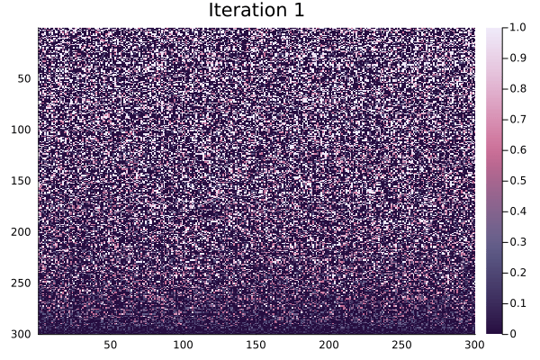

```julia
using Random, LinearAlgebra, Plots

# Set random seed for reproducibility
Random.seed!(1234)

# Generate a 500x500 random matrix
A = randn(500, 500)

# Number of iterations for the QR algorithm
num_iters = 100

# Create an animation object
anim = Animation()

# Reset A and run the animation with fixed color limits
A = randn(300, 300)
# A = A'*A

for i in 1:num_iters
    Q, R = qr(A)
    A = R * Q

    # Generate heatmap with fixed color limits
    heatmap(A, color=:acton, clim=(0, 1), title="Iteration $i",
            axis=true, colorbar=true, yflip=true)

    frame(anim)  # Save the current frame
end

# Save as an animation
gif(anim, "qr_algorithm_convergence.gif", fps=10)
```

```julia
using Random, LinearAlgebra, Plots

# Set random seed for reproducibility
Random.seed!(1234)

# Generate a 500x500 random matrix
A = randn(500, 500)

# Number of iterations for the QR algorithm
num_iters = 100

# Create an animation object
anim = Animation()

# Reset A and run the animation with fixed color limits
A = randn(300, 300)

# Hermitian matrix now:
A = A'*A

for i in 1:num_iters
    Q, R = qr(A)
    A = R * Q

    # Generate heatmap with fixed color limits
    heatmap(A, color=:acton, clim=(0, 1), title="Iteration $i",
            axis=true, colorbar=true, yflip=true)

    frame(anim)  # Save the current frame
end

# Save as an animation
gif(anim, "qr_algorithm_convergence-hermitian.gif", fps=10)
```

## Considering Continuous Functions as Vectors

The idea now is obtaining orthonormal expansions of functions rather than vectors.

We replace $\mathbb{C}^m$ by the Hilbert space $L^2[-1,1]$ of square-absolutely integrable functions on $[-1,1]$. This is a complete normed vector space (a Banach space) which is equipped with the inner product $$ \langle f, g\rangle:=\int_{-1}^1 f(x)^* g(x)\,d x. $$

One may now start with the list of functions $\{ 1, x, x^2, x^3, \ldots\}$ --- analogue of the columns of $A$. Set

$$ q_0(x):= 1. $$

Then continue with the Gram-Schmidt iteration procedure to arrive at

$$ \begin{bmatrix} 1 & x & x^2 & \cdots & x^{n-1} \end{bmatrix} = \begin{bmatrix} q_0(x) & q_1(x) & q_2(x) & \cdots & q_{n-1}(x) \end{bmatrix} \begin{bmatrix} r_{11} & r_{12} & \cdots & r_{1 n} \\ & r_{22} & & \vdots \\ & & \ddots & \\ & & & r_{n n} \end{bmatrix} $$

Here the ``columns'' $q_j(x)$ are orthonormal with respect to the above-mentioned inner product:

$$ \int_{-1}^1 q_i(x)^* q_j(x) d x=\delta_{i j}= \begin{cases}1 & \text { if } i=j \\ 0 & \text { if } i \neq j\end{cases} $$

It is easy to see from Gram-Schmidt iteration that each $q_j(x)$ is a polynomial of degree $j$.

In fact, each $q_j(x)$ is a multiple of what's known as the *Legendre polynomials*, $P_j$, which are conventionally normalized so that $P_j(1)=1$. The first few $P_j$ are

$$ P_0(x)=1, \quad P_1(x)=x, \quad P_2(x)=\frac{3}{2} x^2-\frac{1}{2}, \quad P_3(x)=\frac{5}{2} x^3-\frac{3}{2} x. $$

Like the monomials $1, x, x^2, \ldots$, the sequence of Legendre polynomials spans the spaces of polynomials of successively higher degree.

Moreover, $P_0(x), P_1(x), P_2(x), \ldots$ have the advantage that they are orthogonal, making them far better suited for certain computations.

Computations with orthogonal polynomials form the basis of *spectral methods*, one of the most powerful techniques for the numerical solution of partial differential equations.